# VIS_assignment 03

Mengyao

2020/9/25

# Loading packages

```r
library(sf)
library(tidyverse)
library(ggthemes)
library(ggspatial)
library(units)
library(nngeo)
```

# Loading data

```r
neighborhood <- st_read("https://data.cityofchicago.org/api/geospatial/bbvz-uum9?method=export&format=KML", quiet = TRUE)
park <- st_read("https://data.cityofchicago.org/api/geospatial/ej32-qgdr?method=export&format=KML", quiet = TRUE)
pub_school <- st_read("https://data.cityofchicago.org/api/geospatial/3fhj-xtn5?method=export&format=KML", quiet = TRUE)
bus <- st_read("https://data.cityofchicago.org/download/84eu-buny/text%2Fxml", quiet = TRUE)
```

# Transforming data

I will transform my data to the Illinois East coordinate system.

```r
illinois_east <- "+proj=tmerc +lat_0=36.66666666666666 +lon_0=-88.33333333333333 +k=0.9999749999999999 +x_0=300000 +y_0=0 +ellps=GRS80 +units=m +no_defs "

NEIGHBORHOOD <- neighborhood %>%
  st_transform(crs = illinois_east)

PARK <- park %>%
  st_transform(crs = illinois_east)

PUB_SCHOOL <- pub_school %>%
  st_transform(crs = illinois_east)

BUS <- bus %>%
  st_transform(crs = illinois_east)
```

Quick visualization of the data.

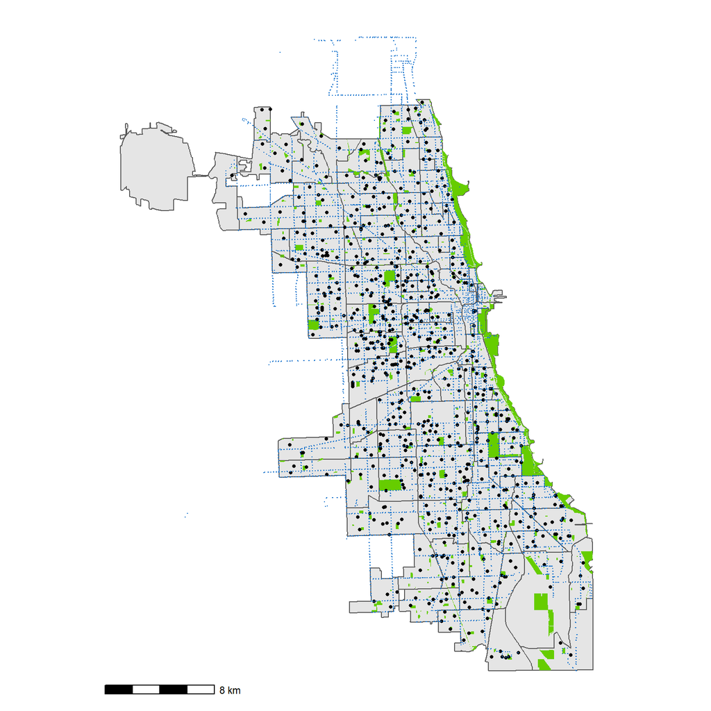

```r
ggplot(NEIGHBORHOOD) +
  geom_sf() +
  geom_sf(data = PARK, fill = "chartreuse3", color = NA) +
  geom_sf(data = PUB_SCHOOL, size = 1) +
  geom_sf(data = BUS, color = "dodgerblue3", size = 0.01) +
  theme_map() +
  annotation_scale()
```

# 1. The number and proportion of A points within a specified distance of B points

## Creating a buffer

I would like to know: how many of the bus stops in Chicago are within 200 meters of a public school? To figure this out, I will create a new polygon layer representing a 200-meter buffer around the public schools. (Metric 1)

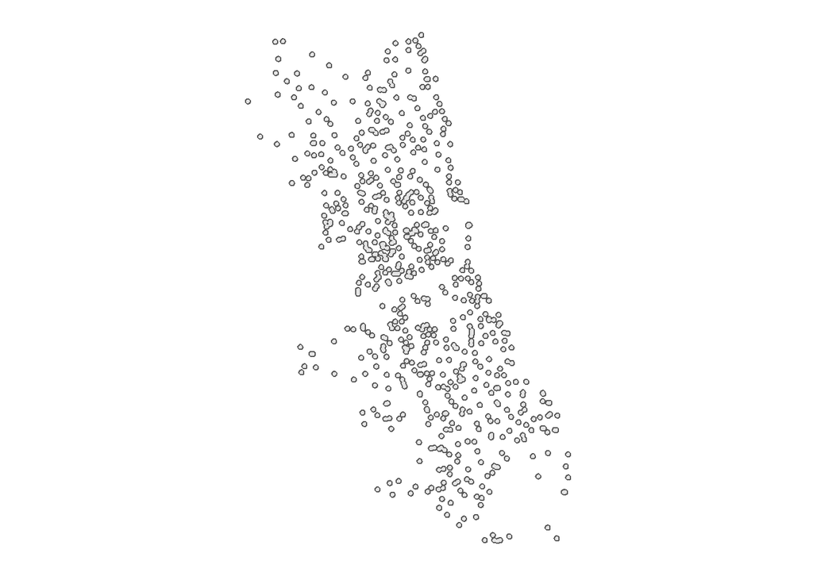

```r
school_buffer <- st_buffer(PUB_SCHOOL, dist = 200) %>%
  st_union()

ggplot(school_buffer) +
  geom_sf() +
  theme_map()
```

## Subsetting points with a polygon

Now I can create a dataframe that only includes bus stops located within the public school buffer. Then we can see how that subset of bus stops looks on the map. I will draw them on top of the public school buffer.

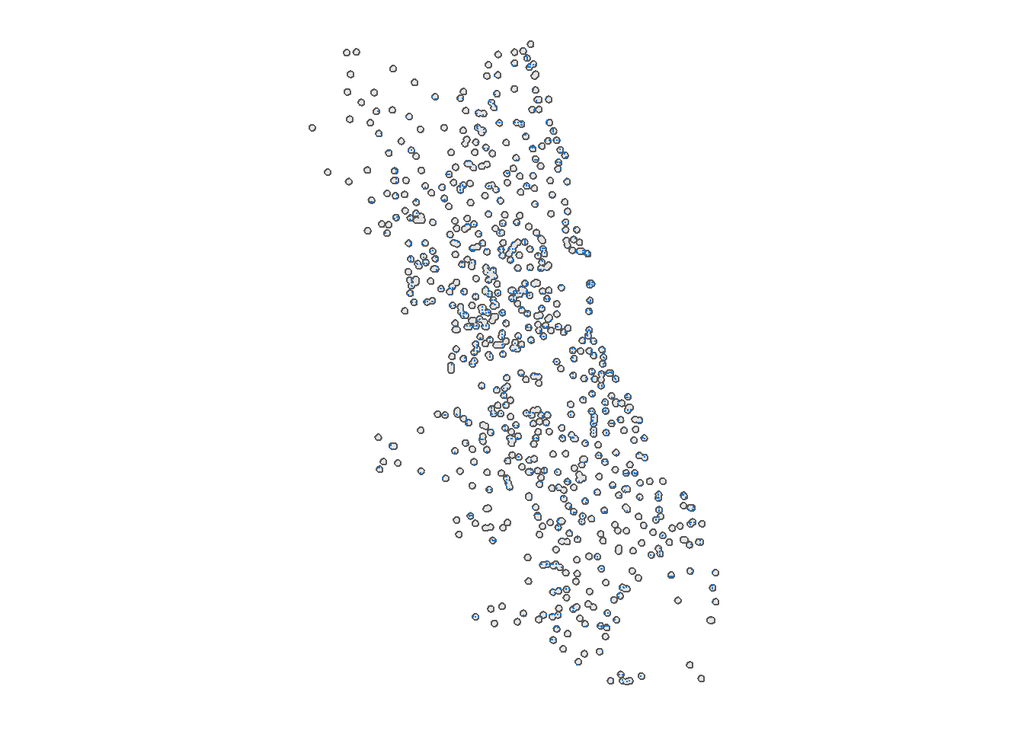

```r
bus_school <- BUS[school_buffer,]

ggplot(school_buffer) +
  geom_sf() +
  geom_sf(data = bus_school, color = "dodgerblue3", size = 0.01) +
  theme_map()
```

Now I will join my two bus dataframes. For any trees that are in the BUS dataset, but not in bus_school, there will be an NA value for the variables Name.y and Description.y. Based on which values of Name.y are NA, I can create a binary variable that indicate whether each bus stop is by a public school.

```r
BUS_new <- BUS %>%
  st_join(bus_school) %>%
  mutate(by_school = !is.na(Name.y))
```

Now we can calculate how many bus stops are within 200 meters of a public school.

```r
n_bus_school <- sum(BUS_new$by_school)
n_bus_school
```

```
## [1] 1539
```

And what percent of all bus stops does this represent?

```r
n_bus <- length(BUS_new$by_school)
pct_bus_school <- n_bus_school / n_bus
pct_bus_school
```

```
## [1] 0.1412575
```

About 14% of all bus stops in Chicago are within 200 meters of a public school.

Visualization of the data.

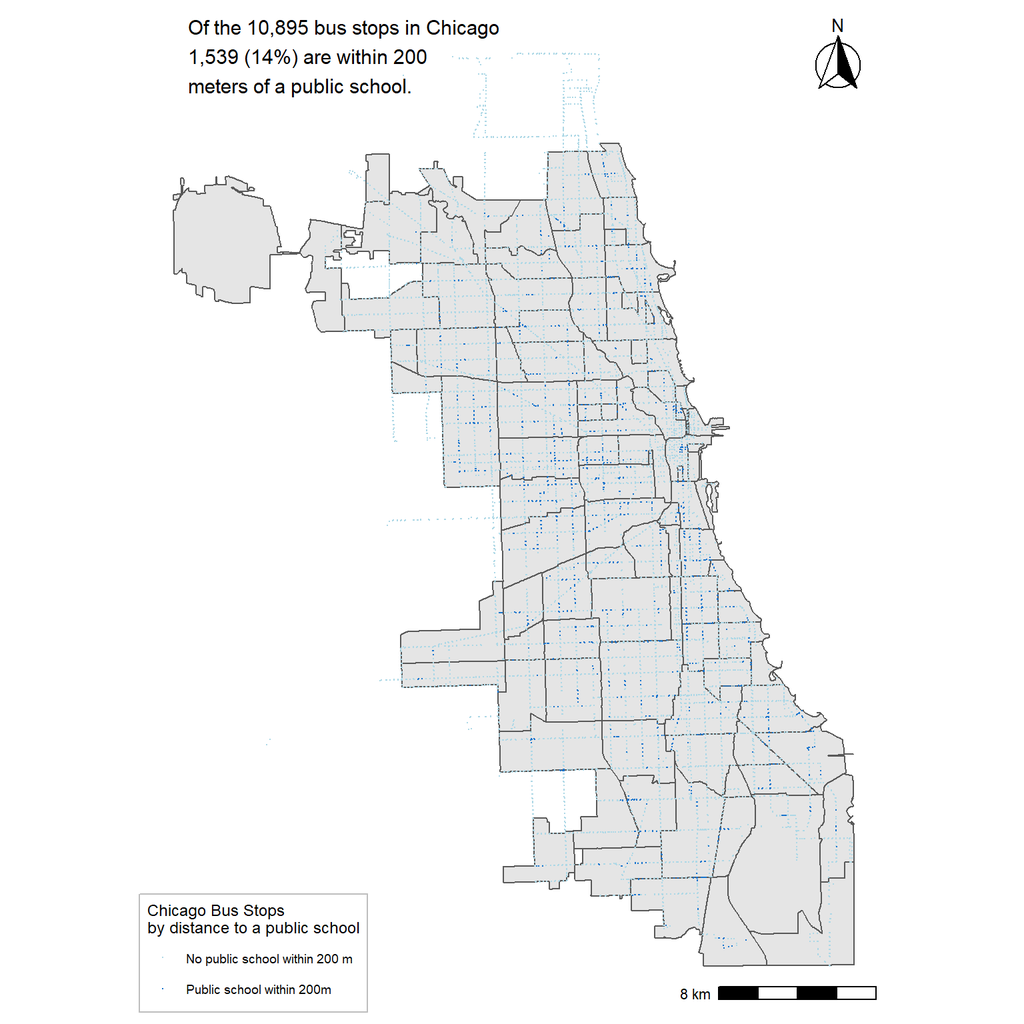

```r
left_side <- st_bbox(BUS_new)$xmin
top_side <- st_bbox(BUS_new)$ymax

ggplot(NEIGHBORHOOD) +
  geom_sf() +
  geom_sf(data = BUS_new, size = 0.1,
          aes(color = by_school)) +
  scale_color_manual(values = c("lightblue", "dodgerblue3"),
                     name = "Chicago Bus Stops\nby distance to a public school",
                     labels = c("No public school within 200 m",
                                "Public school within 200m")) +
  annotation_scale(location = "br") +
  annotation_north_arrow(location = "tr",
                         style = north_arrow_fancy_orienteering()) +
  annotate(geom = "text",
           x = left_side - 4000,
           y = top_side - 2000,
           label = paste("Of the ", prettyNum(n_bus, big.mark = ","), " bus stops in Chicago\n",
                         prettyNum(n_bus_school, big.mark = ","), " (",
                         prettyNum(100*pct_bus_school, digits = 0),
                         "%) are within 200\nmeters of a public school.", sep = ""),
           hjust = 0, vjust = 0, size = 4) +
  theme_map() +
  theme(legend.background = element_rect(fill = alpha("white", 0.5),
                                         color = "gray"))
```

# 2. The number and proportion of A points within C polygons & The average number of A points in each C polygon

I wanted to know how many public schools are in each Chicago neighborhood.

```r
NEIGHBORHOOD_2 <- NEIGHBORHOOD %>%
  mutate(num_schools = lengths(st_covers(NEIGHBORHOOD, PUB_SCHOOL)))
avg_school <- mean(NEIGHBORHOOD_2$num_schools)
prettyNum(avg_school, digits = 0)
```

```
## [1] "7"
```

On average, in each Chicago neighborhood, there are 7 public schools.

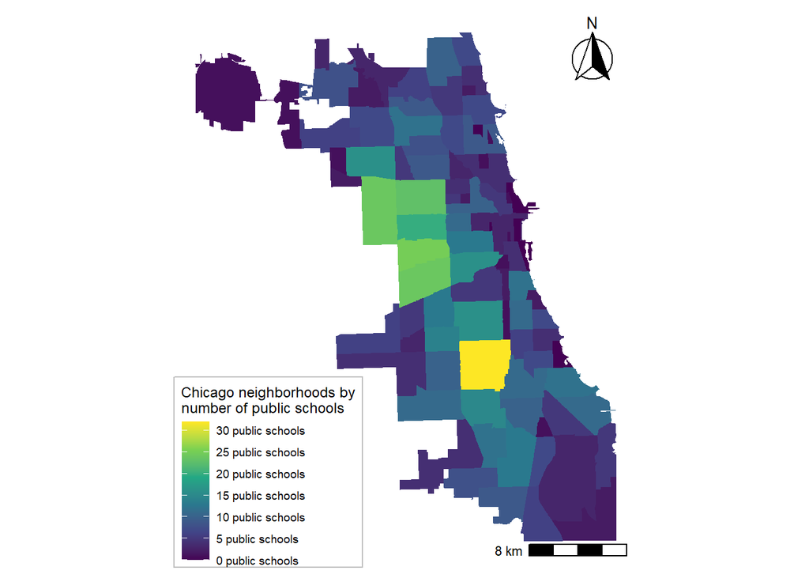

```r
ggplot(NEIGHBORHOOD_2) +
  geom_sf(color = NA,
          aes(fill = num_schools)) +
  scale_fill_viridis_c(name = "Chicago neighborhoods by\nnumber of public schools",
                       breaks = breaks <- seq(0, 35, by = 5),
                       labels = paste(prettyNum(breaks), "public schools")) +
  annotation_scale(location = "br") +
  annotation_north_arrow(location = "tr",
                         style = north_arrow_fancy_orienteering()) +
  theme_map() +
  theme(legend.background = element_rect(fill = alpha("white", 0.5),
                                         color = "gray"))
```

# 3. The average density of B points in each C polygon

I am also interested in the density of bus stops (the number of bus stops per square km) of each Chicago neighborhood.

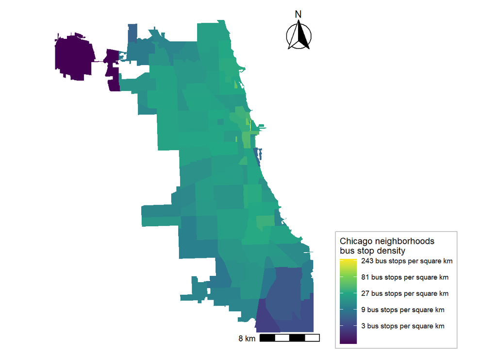

```r
NEIGHBORHOOD_3 <- NEIGHBORHOOD %>%
  mutate(num_bus = lengths(st_covers(NEIGHBORHOOD, BUS_new))) %>%
  mutate(area = set_units(st_area(NEIGHBORHOOD), km^2)) %>%
  mutate(bus_dens = as.numeric(num_bus / area))

ggplot(NEIGHBORHOOD_3) +
  geom_sf(color = NA,
          aes(fill = bus_dens)) +
  scale_fill_viridis_c(name = "Chicago neighborhoods\nbus stop density",
                       trans = "log",
                       breaks = breaks <- c(3, 9, 27, 81, 243),
                       labels = paste(prettyNum(breaks), "bus stops per square km")) +
  annotation_scale(location = "br") +
  annotation_north_arrow(location = "tr",
                         style = north_arrow_fancy_orienteering()) +
  theme_map() +
  theme(legend.position = "right",
        legend.background = element_rect(fill = alpha("white", 0.5),
                                         color = "gray"))
```

# 4. The average density of A points in each C polygon

I would like to know the density of public schools (the number of public schools per square km) of each Chicago neighborhood.

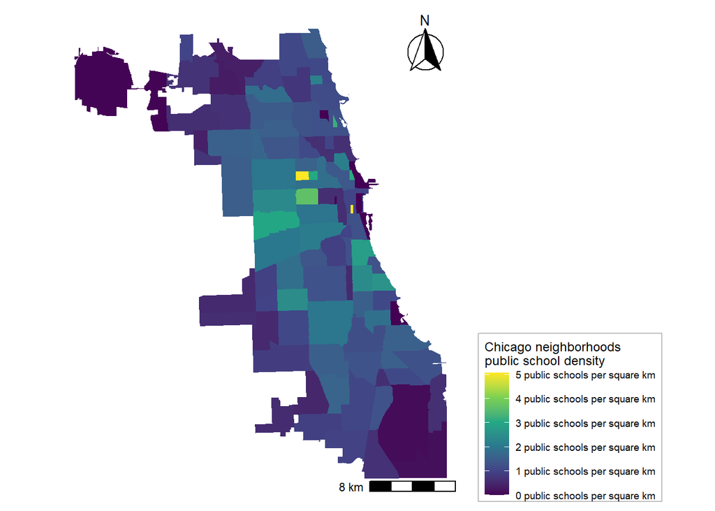

```r
NEIGHBORHOOD_4 <- NEIGHBORHOOD %>%
  mutate(num_school = lengths(st_covers(NEIGHBORHOOD, PUB_SCHOOL))) %>%
  mutate(area = set_units(st_area(NEIGHBORHOOD), km^2)) %>%
  mutate(school_dens = as.numeric(num_school / area))

ggplot(NEIGHBORHOOD_4) +
  geom_sf(color = NA,
          aes(fill = school_dens)) +
  scale_fill_viridis_c(name = "Chicago neighborhoods\npublic school density",
                       breaks = breaks <- seq(0,5,by=1),
                       labels = paste(prettyNum(breaks), "public schools per square km")) +
  annotation_scale(location = "br") +
  annotation_north_arrow(location = "tr",
                         style = north_arrow_fancy_orienteering()) +
  theme_map() +
  theme(legend.position = "right",
        legend.background = element_rect(fill = alpha("white", 0.5),
                                         color = "gray"))
```

# 5. The average (Euclidean) distance between A points and their nearest respective B points

I want to know how far each school is from a bus stop.

I would like to thank Carole for clarification of the st_nn function. At first, I encountered this error message: Problem with mutate() input bus_dist. x Query and data tables must have same dimensions i Input bus_dist is st_nn(PUB_SCHOOL, BUS, returnDist = TRUE)$dist. As Carole suggested, the locations of my bus stops are in (x,y,z) coordinates (so - three dimensions, with a z coordinate that supposedly represents elevation, but they’re all set to zero, so it actually means nothing), and my school locations are in (x, y) coordinates (so, two dimensions). I should convert the bus stop locations to two dimensions (removing all the z coordinates by st_zm function) before using the st_nn function.

```r
BUS <- BUS %>%
  mutate(geometry = st_zm(geometry))
PUB_SCHOOL_2 <- PUB_SCHOOL %>%
  mutate(bus_dist = st_nn(PUB_SCHOOL, BUS,
                         returnDist = TRUE)$dist)  %>%
  mutate(bus_dist = as.numeric(bus_dist))
```

```
## projected points
```

Now I can calculate the average distance from a public school to the nearest bus stop.

```r
avg_bus_dist <- mean(PUB_SCHOOL_2$bus_dist)
avg_bus_dist
```

```
## [1] 171.3107
```

On average, a public school is about 171 meters away from the nearest bus stop.

Visualizing how far each public school is from a bus stop. I use coord_sf function to set the map extents to just the area where the public schools are.

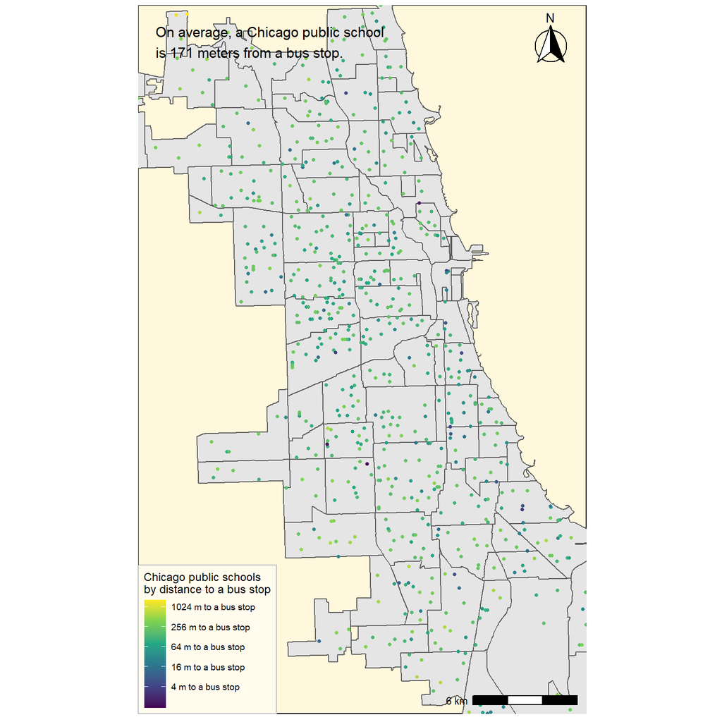

```r
right_side <- st_bbox(PUB_SCHOOL_2)$xmax
left_side <- st_bbox(PUB_SCHOOL_2)$xmin
top_side <- st_bbox(PUB_SCHOOL_2)$ymax
bottom_side <- st_bbox(PUB_SCHOOL_2)$ymin

ggplot(NEIGHBORHOOD) +
  geom_sf() +
  geom_sf(data = PUB_SCHOOL_2, size = 1,
          aes(color = bus_dist)) +
  coord_sf(xlim = c(left_side, right_side),
           ylim = c(bottom_side, top_side), expand = FALSE) +
  scale_color_viridis_c(name = "Chicago public schools\nby distance to a bus stop",
                        trans = "log",
                        breaks = breaks <- c(4, 16, 64, 256, 1024),
                        labels = paste(prettyNum(breaks), "m to a bus stop")) +
  annotation_scale(location = "br") +
  annotation_north_arrow(location = "tr",
                         style = north_arrow_fancy_orienteering()) +
  annotate(geom = "text", x = left_side + 1000,
           y = top_side - 3000,
           label = paste("On average, a Chicago public school\nis ",
                         prettyNum(avg_bus_dist, digits = 3),
                         " meters from a bus stop.", sep = ""),
           hjust = 0, vjust = 0, size = 4) +
  theme_map() +
  theme(panel.background = element_rect(fill = "cornsilk1"),
        legend.background = element_rect(fill = alpha("white", 0.5),
                                         color = "gray"))
```

# 6. The number and proportion of C polygons that overlap with D polygons

I would like to know which neighborhoods have parks in them.

```r
NEIGHBORHOOD_5 <- NEIGHBORHOOD %>%
  mutate(num_park = lengths(st_overlaps(NEIGHBORHOOD, PARK))) %>%
  mutate(has_park = num_park >0)

n_park_nhoods <- sum(NEIGHBORHOOD_5$has_park)
pct_park_nhoods <- n_park_nhoods / nrow(NEIGHBORHOOD_5)
n_park_nhoods
```

```
## [1] 48
```

```r
pct_park_nhoods
```

```
## [1] 0.4897959
```

In total, 48 neighborhoods (49%) have parks in them.

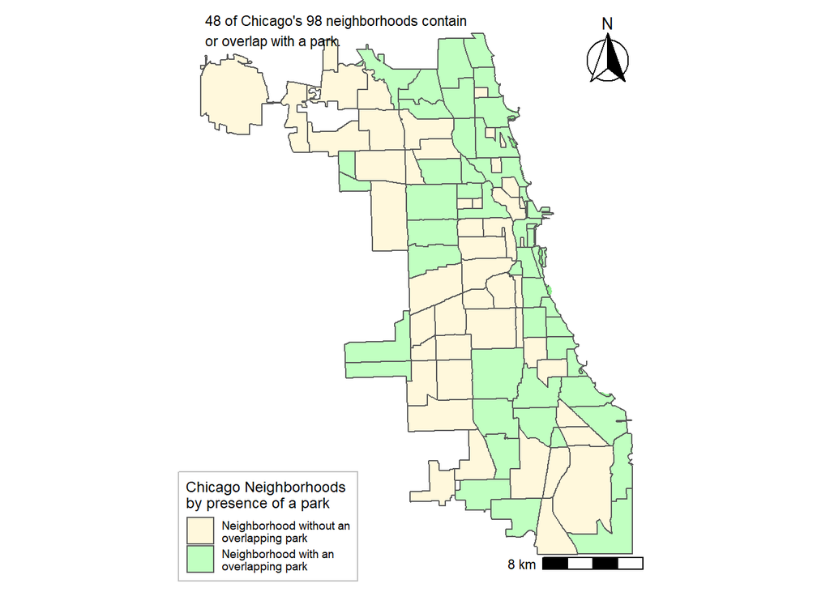

```r
left_side <- st_bbox(PARK)$xmin
top_side <- st_bbox(PARK)$ymax

ggplot(PARK) +
  geom_sf(fill = "lightgreen", color = NA) +
  geom_sf(data = NEIGHBORHOOD_5,
           aes(fill = has_park)) +
  scale_fill_manual(values = c("cornsilk1", "darkseagreen1"),
                    name = "Chicago Neighborhoods\nby presence of a park",
                    labels = c("Neighborhood without an\noverlapping park",
                               "Neighborhood with an\noverlapping park")) +
  annotation_scale(location = "br") +
  annotation_north_arrow(location = "tr",
                         style = north_arrow_fancy_orienteering()) +
  annotate(geom = "text",
           x = left_side - 8000,
           y = top_side - 1000,
           label = paste(n_park_nhoods, "of Chicago's", length(NEIGHBORHOOD_5$Name), "neighborhoods contain\nor overlap with a park."),
           hjust = 0, vjust = 0, size = 3) +
  theme_map() +
  theme(legend.background = element_rect(fill = alpha("white", 0.5),
                                          color = "gray"))
```